# Statystyka opisowa w R - studium przypadku

**Przedmiotowe dane zawierają informacje z ankiet przeprowadzonych Wśród mieszkańców jednego z osiedla mieszkaniowego w Poznaniu. Dane te są fikcyjne i mają charakter poglądowy.**

Załadowanie bibliotek:

```r
library(readxl)
library(dplyr)
```

```r
library(ggplot2)
library(forcats)
library(tidyr)
library(knitr)
library(kableExtra)
```

Załadowanie danych:

```r
ankieta <- read_excel("F:/R/dane.xlsx", sheet = "dane źródłowe ")
```

Podgląd danych:

```r
ankieta
```

| lp | płeć | wykształcenie | dochody | wydatki_żywność | sklep |
| --- | --- | --- | --- | --- | --- |
| 1 | K | P | 2150 | 683 | market spożywczy |
| 2 | K | Z | 2665 | 756 | sklepik osiedlowy |
| 3 | K | Z | 3060 | 901 | hipermarket |
| 4 | K | Z | 2690 | 771 | sklepik osiedlowy |
| 5 | K | Z | 2641 | 717 | market spożywczy |
| 6 | K | Z | 2715 | 728 | hipermarket |
| 7 | K | Z | 3181 | 828 | market spożywczy |
| 8 | K | Z | 2595 | 710 | sklepik osiedlowy |
| 9 | K | Z | 3135 | 841 | sklepik osiedlowy |
| 10 | K | Z | 2995 | 789 | sklepik osiedlowy |

[output cut: 121 more lines]

```r
poznaj.dane<- function(x) {

    rozmiar.zbioru<-dim(x)
    liczba.obserwacji<-nrow(x)
    liczba.zmiennych<-ncol(x)
    liczba.duplikatów<-sum(duplicated(x))
    liczba.na<-sum(is.na(x))
    liczba.null<-sum(is.null(x))
    opis<-data.frame(liczba.obserwacji,liczba.zmiennych,
              liczba.duplikatów, liczba.na, liczba.null)
    opis<-pivot_longer(data = opis, cols = 1:5,
                        names_to = "cecha", values_to = "liczebnosć")
    return(opis)
}
```

Informacja szczegółowa o danych:

```r
poznaj.dane(ankieta)
```

| cecha | liczebnosć |
| --- | --- |
| liczba.obserwacji | 131 |
| liczba.zmiennych | 6 |
| liczba.duplikatów | 3 |
| liczba.na | 14 |
| liczba.null | 0 |

Z powyższych informacji wynika, że w danych znajdują się duplikaty, obserwacje puste, zatem dane te zostaną oczyszczone.

- braki danych

```r
braki.obserwacji<-data.frame(nr.wiersza=rownames(ankieta),liczba.pustych=rowSums(is.na(ankieta)),proc.pustych=round(100*rowSums(is.na(ankieta))/ncol(ankieta),2))%>%filter(liczba.pustych>0)

braki.zmiennych<- data.frame(liczba.pustych=colSums(is.na(ankieta)),proc.pustych=round(100*colSums(is.na(ankieta))/nrow(ankieta),2))%>%filter(liczba.pustych>0)
```

```r
braki.zmiennych
```

|  | liczba.pustych | proc.pustych |
| --- | --- | --- |
| płeć | 3 | 2.29 |
| wykształcenie | 3 | 2.29 |
| dochody | 3 | 2.29 |
| wydatki_żywność | 2 | 1.53 |
| sklep | 3 | 2.29 |

```r
braki.obserwacji
```

| nr.wiersza | liczba.pustych | proc.pustych |
| --- | --- | --- |
| 129 | 4 | 66.67 |
| 130 | 5 | 83.33 |
| 131 | 5 | 83.33 |

```r
obserwacje.z.brakami<-ankieta[!complete.cases(ankieta),]
obserwacje.z.brakami
```

| lp | płeć | wykształcenie | dochody | wydatki_żywność | sklep |
| --- | --- | --- | --- | --- | --- |
| 154 | NA | NA | NA | 1243 | NA |
| 158 | NA | NA | NA | NA | NA |
| 159 | NA | NA | NA | NA | NA |

- duplikaty

```r
obserwacje.duplikaty<-ankieta[duplicated(ankieta),]
```

```r
obserwacje.duplikaty
```

| lp | płeć | wykształcenie | dochody | wydatki_żywność | sklep |
| --- | --- | --- | --- | --- | --- |
| 125 | M | W | 3319 | 870 | hipermarket |
| 115 | M | W | 4364 | 1110 | hipermarket |
| 116 | M | W | 4645 | 1243 | market spożywczy |

Z uwagi na niewielką liczbę braków, wiersze z brakami danych zostaną usunięte, nie wpłynie to na wynika analizy, tym bardziej, że typ tych braków nie wynika z charakteru danych , a jedynie z błędnie uzupełnionej tabeli źródłowej.

Ponadto należny zauważyć, że 3 wiersze zostały w trakcje sporządzania tabeli danych zdublowane, zatem i te obserwacje zostaną usunięte.

```r
# usunięcie zduplikowanych

ankieta<-ankieta[!duplicated(ankieta),]
```

```r
# usunięcie braków
ankieta<-na.omit(ankieta)
```

Informacja na temat danych po ich oczyszczeniu

```r
poznaj.dane(ankieta)
```

| cecha | liczebnosć |
| --- | --- |
| liczba.obserwacji | 125 |
| liczba.zmiennych | 6 |
| liczba.duplikatów | 0 |
| liczba.na | 0 |
| liczba.null | 0 |

Z powyższego wynika, że dane zostały wstępnie oczyszczone, nie występują braki danych oraz obserwacje zdublowane.

Zatem można przejść do analizy opisowej.

Dokonano podziału danych wg typów zmiennych, jest to niezbędne do wybory odpowiedniego parametru opisu statystycznego

```r
zmienne.ilościowe<-names(select(ankieta,4,5))
zmienne.jakościowe<-names(select(ankieta,2,3,6))
```

zmienne ilościowe:

```r
zmienne.ilościowe
```

```
## [1] "dochody"         "wydatki_żywność"
```

zmienne jakosciowe:

```r
zmienne.jakościowe
```

```
## [1] "płeć"          "wykształcenie" "sklep"
```

Analiza zmiennych jakościowych

1. płeć
2. wykształcenie
3. typ sklepu

```r
# przekonwertowanie na faktory

    ankieta$płeć<-as.factor(ankieta$płeć)
    ankieta$wykształcenie<-as.factor(ankieta$wykształcenie)
    ankieta$sklep<-as.factor(ankieta$sklep)
```

ustalenie poziomów poszczególnych zmiennych:

```r
levels(ankieta$wykształcenie)
```

```
## [1] "P" "Ś" "W" "Z"
```

```r
levels(ankieta$płeć)
```

```
## [1] "K" "M"
```

```r
levels(ankieta$sklep)
```

```
## [1] "hipermarket"       "market spożywczy"  "sklepik osiedlowy"
```

Należy zawszyć, że kolejności poziomów zmiennej" wykształcenie" jest nieprawidłowa, zatem pokonano zmiany ich pozycji

- zmiana kolejności czynników

```r
ankieta$wykształcenie<-ordered(ankieta$wykształcenie,levels=c("P","Z","Ś","W"))
```

po zmianie kolejności:

```r
levels(ankieta$wykształcenie)
```

```
## [1] "P" "Z" "Ś" "W"
```

dla czytelności analizy poziomy te zostaną również przekodowane na pełne nazwy

- poziomów wykształcenia

```r
ankieta$wykształcenie<-recode_factor(ankieta$wykształcenie,"P"="podstawowe", "Z"="zawodowe","Ś"="średnie","W"="wyższe")
```

po zmianie

```r
 levels(ankieta$wykształcenie)
```

```
## [1] "podstawowe" "zawodowe"   "średnie"    "wyższe"
```

- poziomów płci:

```r
ankieta$płeć<-recode_factor(ankieta$płeć,"K"="Kobieta", "M"="Mężczyzna")
```

po zmianie:

```r
  levels(ankieta$płeć)
```

```
## [1] "Kobieta"   "Mężczyzna"
```

określenie liczebności, % częstości zmiennych jakościowych oraz ich wykresy

**PŁEĆ**

```r
ankieta%>%group_by(płeć)%>%summarise(liczebność=n(), proc=liczebność/length(ankieta$płeć)*100)
```

| płeć | liczebność | proc |
| --- | --- | --- |
| Kobieta | 56 | 44.8 |
| Mężczyzna | 69 | 55.2 |

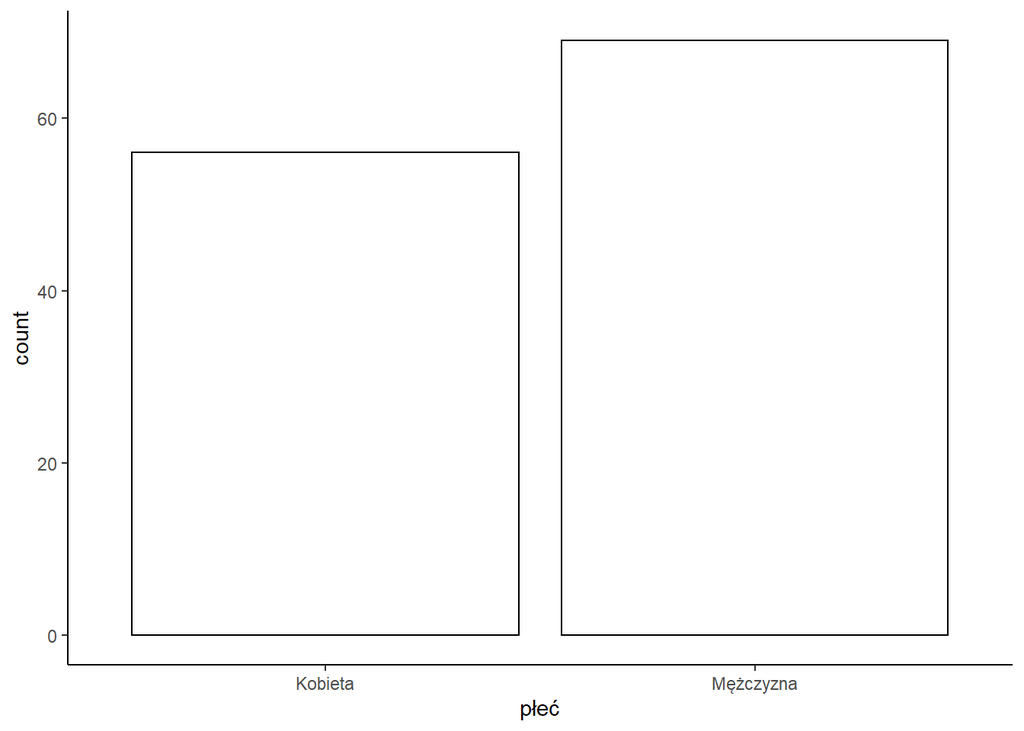

```r
ggplot(ankieta, aes(płeć))+ geom_bar(fill=NA, colour="black")+theme_classic()
```

**WYKSZTAŁCENIE**

```r
ankieta%>%group_by(wykształcenie)%>%summarise(liczebność=n(), proc=liczebność/length(ankieta$wykształcenie)*100)
```

| wykształcenie | liczebność | proc |
| --- | --- | --- |
| podstawowe | 1 | 0.8 |
| zawodowe | 22 | 17.6 |
| średnie | 37 | 29.6 |
| wyższe | 65 | 52.0 |

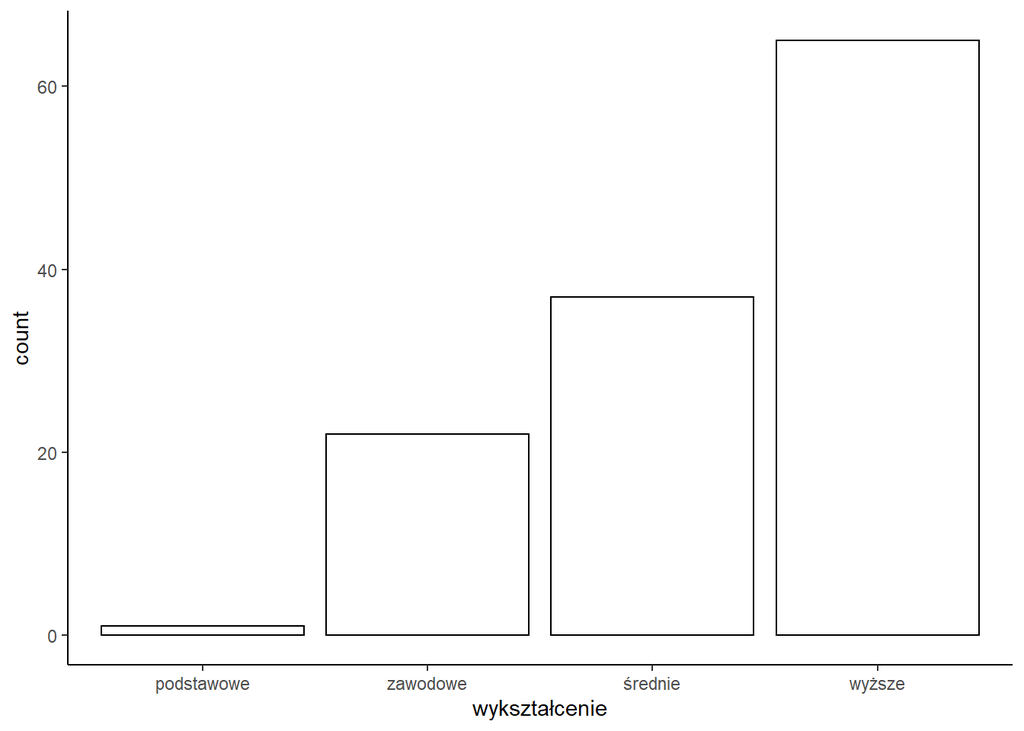

```r
ggplot(ankieta, aes(wykształcenie))+ geom_bar(fill=NA, colour="black")+theme_classic()
```

**TYP SKLEPU**

```r
ankieta%>%group_by(sklep)%>%summarise(liczebność=n(), proc=liczebność/length(ankieta$sklep)*100)
```

| sklep | liczebność | proc |
| --- | --- | --- |
| hipermarket | 42 | 33.6 |
| market spożywczy | 34 | 27.2 |
| sklepik osiedlowy | 49 | 39.2 |

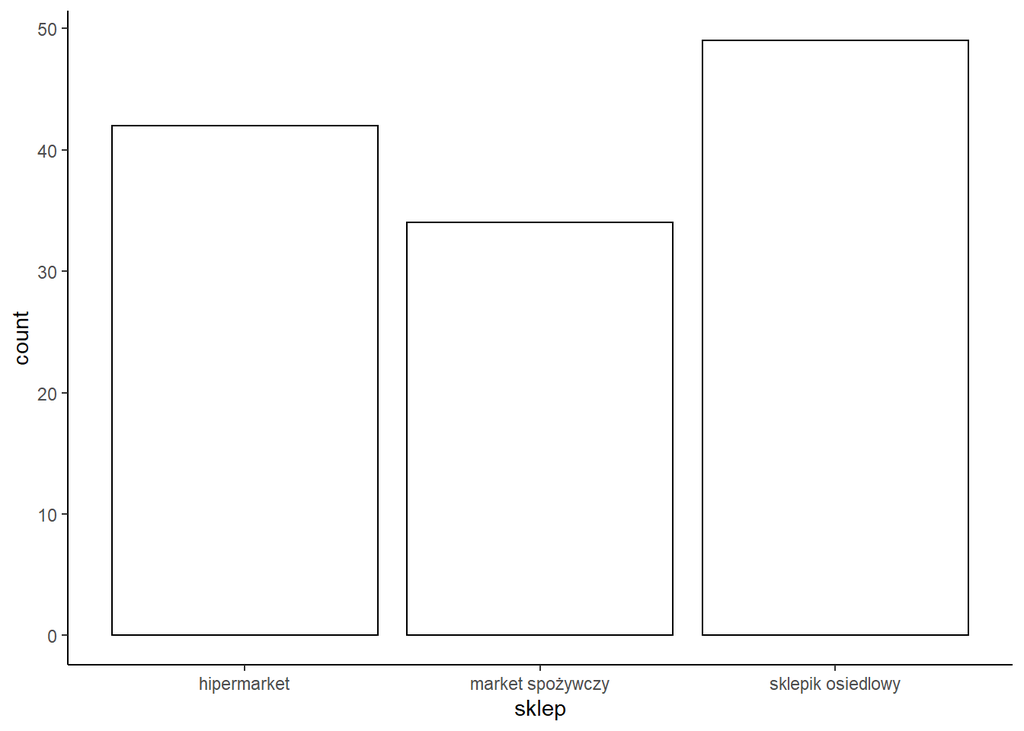

```r
ggplot(ankieta, aes(sklep))+ geom_bar(fill=NA, colour="black")+theme_classic()
```

ZMIENNE ILOŚCIOWE

Do analizy zostaną przyjęte zmienne: - dochody - wydatki_zywnosć

podgląd danych w ujęciu graficznym - ustalenie rozkładów poszczególnych zmiennych oraz ich charakterystyk liczbowych.

```r
# utworzenie funkcji obliczającej miary statystyczne


miary.statystyczne<- function(x) {


min<-min(x)
max<-max(x)
srednia<-mean(x)
q1<-quantile(x, probs = 0.25)
mediana<-median(x)
q3<-quantile(x, probs = 0.75)

 mode <- function(x) {
      unique_num <- unique(x)
      unique_num [which.max(tabulate(match(x, unique_num )))]
 }

rozstęp<-max(x)-min(x)

rozstęp_międzykwarylowy = q3-q1
odchylenie_ćwiartkowe<- rozstęp_międzykwarylowy/2


dl<-length(x)-1

variancja<-sum((x-srednia)^2)/dl
odchylenie_standardowe<-sqrt(variancja)


odchylenie_przecietne<-mean(sum(abs(x-srednia)))/dl


kl_wsp_zmienności<-(odchylenie_standardowe/srednia)*100
poz_wsp_zmiennosci<-(rozstęp_międzykwarylowy/mediana)*100


mode <- function(x) {
      unique_num <- unique(x)
      unique_num [which.max(tabulate(match(x, unique_num )))]
}

ws.asymetri<-srednia-mode(x)

ws.asymetrii.pearson<-round(ws.asymetri/odchylenie_standardowe,2)


m3<-sum((x-srednia)^3)/dl
m4<-sum((x-srednia)^4)/dl


stand.m3<-round(m3/(odchylenie_standardowe)^3,2)

ws.asymertii.wew<-round((q1+q3)-(2*mediana),2)

stand.m4<-round(m4/(odchylenie_standardowe)^4,2)

eksces<-round(m4/(odchylenie_standardowe)^4,2)-3




kl_typ_obszar_zmienności.a<-srednia - odchylenie_standardowe
kl_typ_obszar_zmienności.b<- srednia + odchylenie_standardowe


poz_typ_obszar_zmienności.a<- mediana- odchylenie_ćwiartkowe
poz_typ_obszar_zmienności.b<- mediana + odchylenie_ćwiartkowe




miary<-data.frame(miara=c("min", "max","średnia", "Q1.25%", "mediana", "Q3.75%","rozstęp", "rozstęp_międzykwarylowy", "odchylenie_ćwiartkowe", 'variancja', "odchylenie_standardowe", "odchylenie_przecietne", "kl_wsp_zmienności", "poz_wsp_zmiennosci", "wsp asymetrii", "ws.asymetrii.pearson", "stand.m3","ws.asymertii.wew", "stand.m4", "eksces"), wartość=c(min, max, srednia, q1, mediana, q3,rozstęp, rozstęp_międzykwarylowy, odchylenie_ćwiartkowe, variancja, odchylenie_standardowe, odchylenie_przecietne, kl_wsp_zmienności, poz_wsp_zmiennosci, ws.asymetri, ws.asymetrii.pearson, stand.m3, ws.asymertii.wew, stand.m4, eksces ))

return(miary)


}
```

1. DOCHODY
- wykresy:

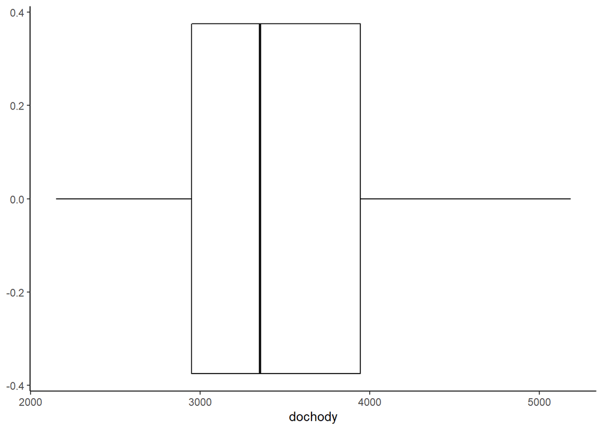

```r
ggplot(ankieta, aes(dochody))+ geom_boxplot(fill=NA, colour="black")+theme_classic()
```

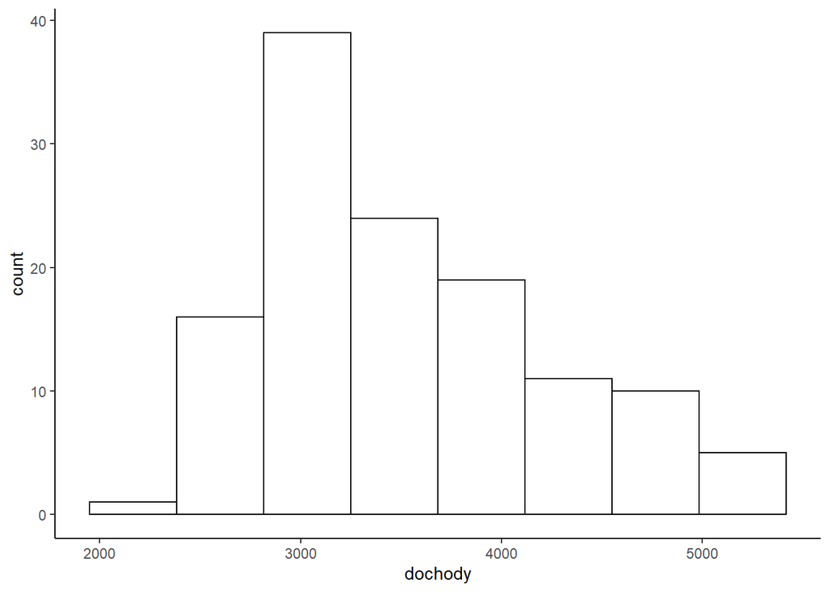

```r
ggplot(ankieta, aes(dochody))+ geom_histogram( bins=8, fill=NA, color="black", alpha=0.9)+ theme_classic()
```

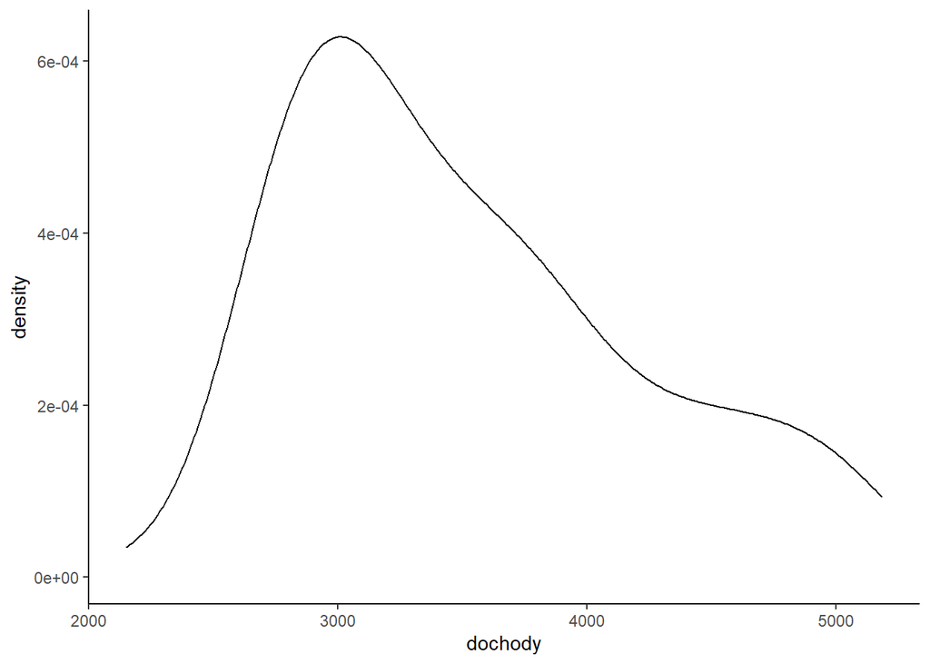

```r
ggplot(ankieta, aes(dochody))+ geom_density(fill=NA, colour="black")+theme_classic()
```

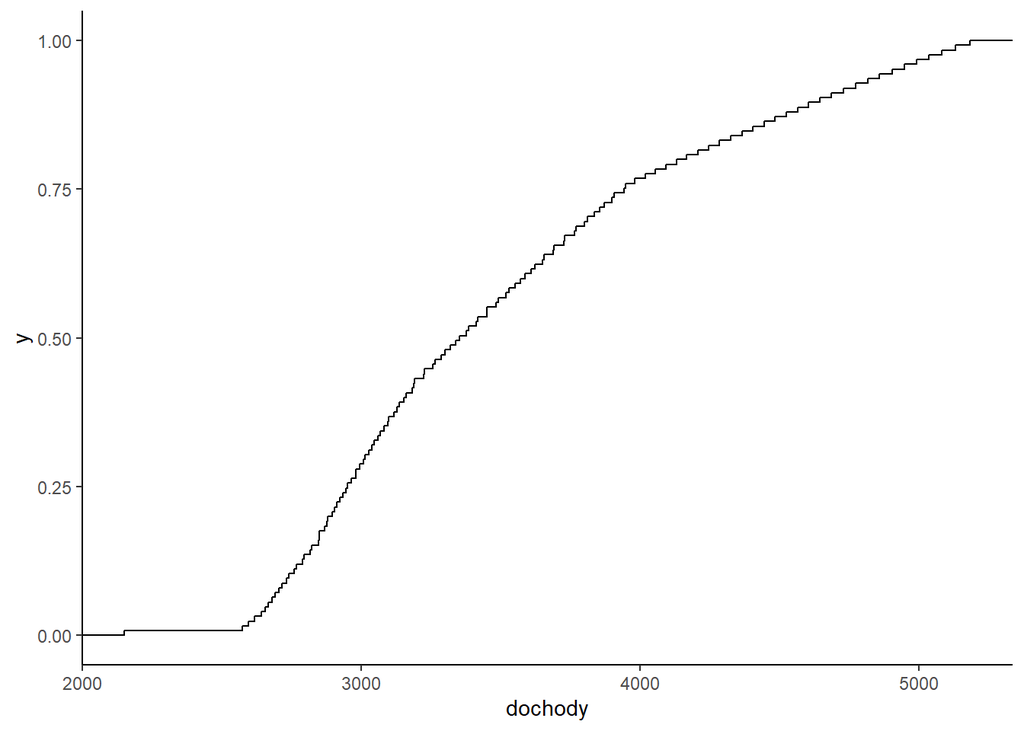

```r
ggplot(ankieta, aes(dochody))+stat_ecdf()+ theme_classic()
```

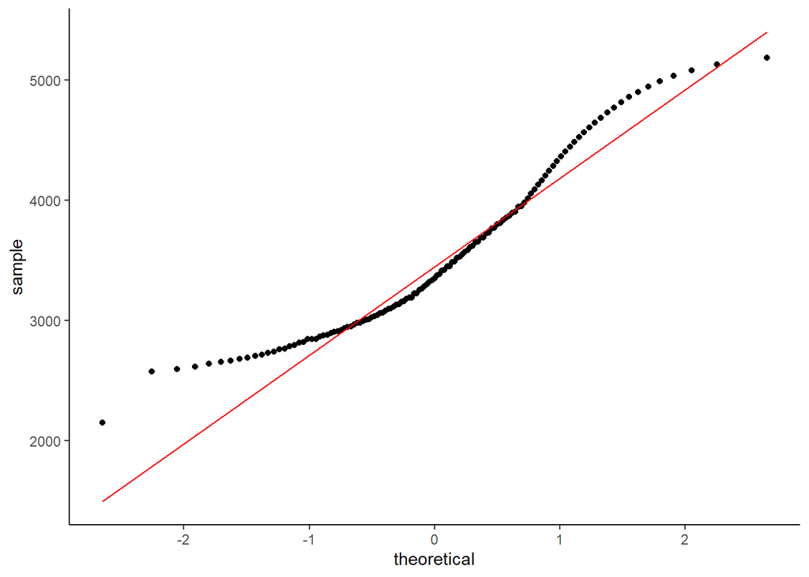

```r
ggplot(ankieta, aes(sample = dochody)) +stat_qq() + stat_qq_line(colour="red")+ theme_classic()
```

- miary statystyczne

  ```r
  kable( miary.statystyczne(ankieta$dochody), digits = 2)
  ```

  | miara | wartość |
  | --- | --- |
  | min | 2150.00 |
  | max | 5183.00 |
  | średnia | 3515.62 |
  | Q1.25% | 2950.00 |
  | mediana | 3352.00 |
  | Q3.75% | 3943.00 |
  | rozstęp | 3033.00 |
  | rozstęp_międzykwarylowy | 993.00 |
  | odchylenie_ćwiartkowe | 496.50 |
  | variancja | 494821.06 |
  | odchylenie_standardowe | 703.44 |
  | odchylenie_przecietne | 586.12 |
  | kl_wsp_zmienności | 20.01 |
  | poz_wsp_zmiennosci | 29.62 |
  | wsp asymetrii | 667.62 |
  | ws.asymetrii.pearson | 0.95 |
  | stand.m3 | 0.66 |
  | ws.asymertii.wew | 189.00 |
  | stand.m4 | 2.49 |
  | eksces | -0.51 |

2. WYDATKI NA ŻYWNOŚĆ
- wykresy:

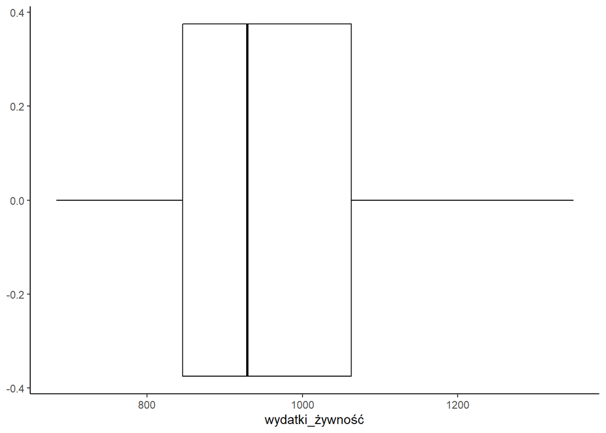

```r
ggplot(ankieta, aes(wydatki_żywność))+ geom_boxplot(fill=NA, colour="black")+theme_classic()
```

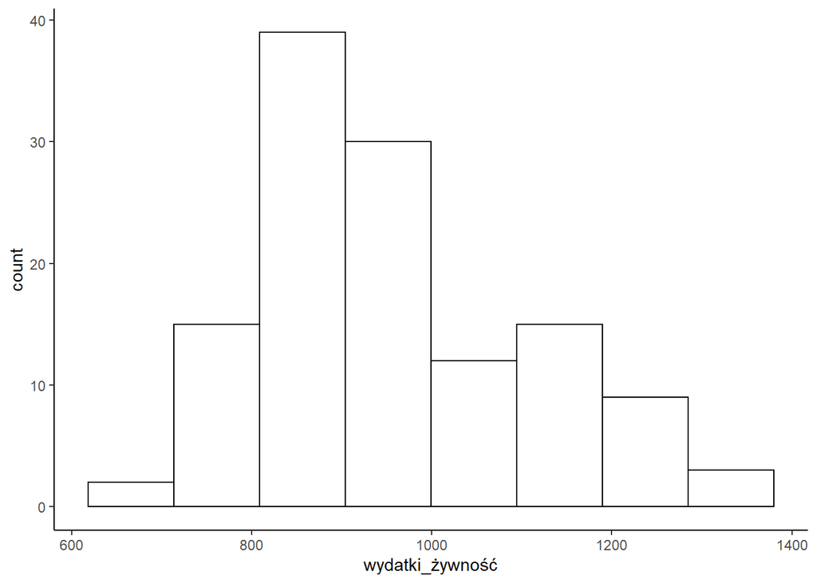

```r
ggplot(ankieta, aes(wydatki_żywność))+ geom_histogram( bins=8, fill=NA, color="black", alpha=0.9)+ theme_classic()
```

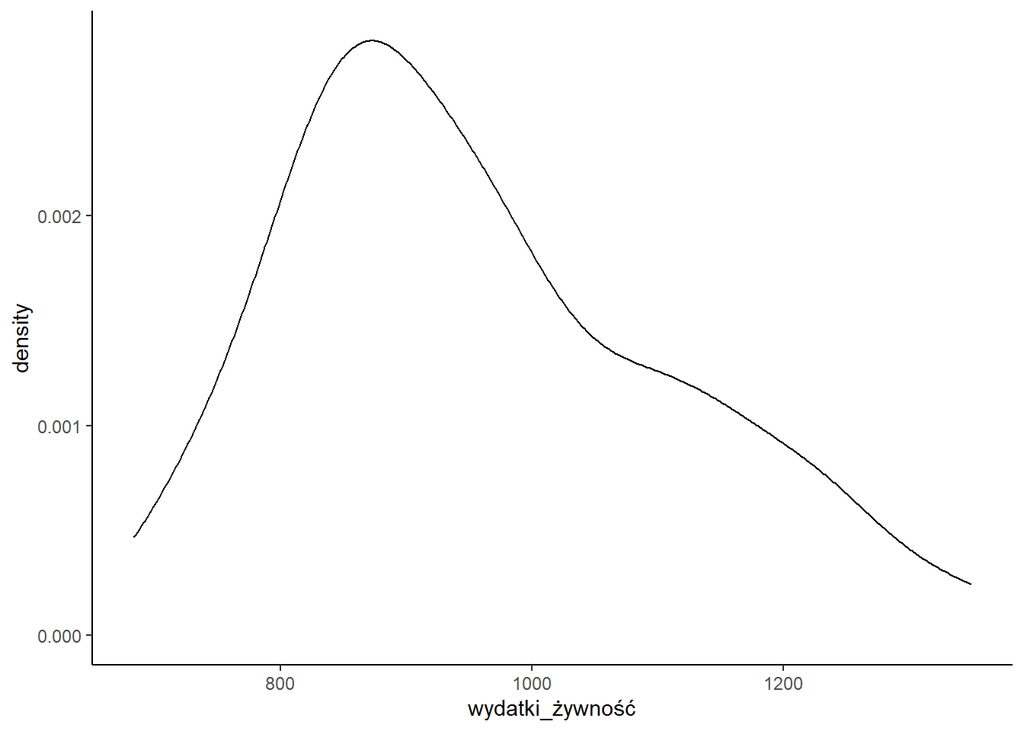

```r
ggplot(ankieta, aes(wydatki_żywność))+ geom_density(fill=NA, colour="black")+theme_classic()
```

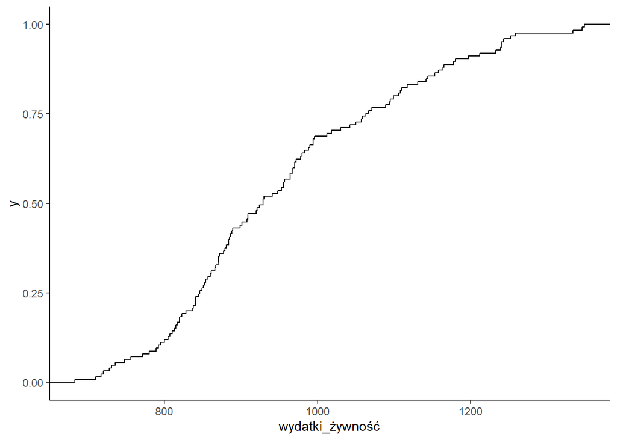

```r
ggplot(ankieta, aes(wydatki_żywność))+stat_ecdf()+ theme_classic()
```

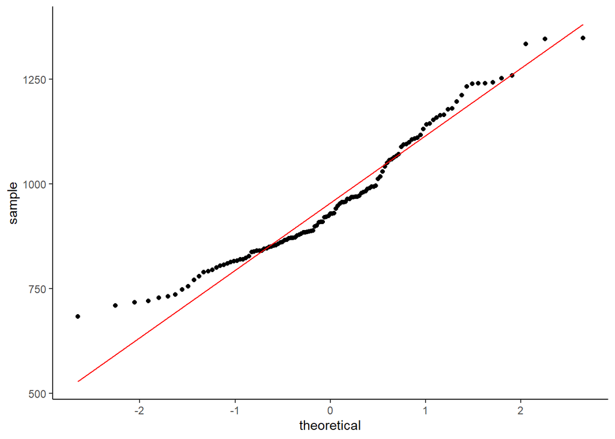

```r
ggplot(ankieta, aes(sample = wydatki_żywność)) +stat_qq() + stat_qq_line(colour="red")+ theme_classic()
```

- miary:

  ```r
   kable( miary.statystyczne(ankieta$wydatki_żywność), digits = 2)
  ```

  | miara | wartość |
  | --- | --- |
  | min | 683.00 |
  | max | 1349.00 |
  | średnia | 958.18 |
  | Q1.25% | 846.00 |
  | mediana | 929.00 |
  | Q3.75% | 1063.00 |
  | rozstęp | 666.00 |
  | rozstęp_międzykwarylowy | 217.00 |
  | odchylenie_ćwiartkowe | 108.50 |
  | variancja | 23475.44 |
  | odchylenie_standardowe | 153.22 |
  | odchylenie_przecietne | 125.53 |
  | kl_wsp_zmienności | 15.99 |
  | poz_wsp_zmiennosci | 23.36 |
  | wsp asymetrii | 117.18 |
  | ws.asymetrii.pearson | 0.76 |
  | stand.m3 | 0.60 |
  | ws.asymertii.wew | 51.00 |
  | stand.m4 | 2.62 |
  | eksces | -0.38 |